# Séries IMDB - 01

Dandara Sousa

19 de maio de 2017

### O conjunto de dados

Nosso conjunto de dados consiste em séries e suas respectivas avaliações que estão disponíveis no [IMDB](http://imdb.com). Essas são as séries que compõem os dados:

```r
series <- read.csv("../data/series_from_imdb.csv", encoding = "UTF-8" )

unique(series$series_name)
```

```
##   [1] 13 Reasons Why
##   [2] How to Get Away with Murder
##   [3] Mr Robot
##   [4] Sense8
##   [5] Sherlock
##   [6] Are You There
##   [7] Ashes to Ashes
##   [8] Franklin And Bash
##   [9] Monk
##  [10] Mistresses
##  [11] Nikita
##  [12] Roma
##  [13] Tru Calling
##  [14] Happy Town
##  [15] American Dad
```

[output cut: 497 more lines]

### O subconjunto de séries

Dentre as séries do IMDB a seguintes foram escolhidas para serem avaliadas. Para cada série usaremos as seguintes informações: nome da série, a temporada de cada episódio e a nota dada a cada episódio. Os votos dos usuários do site são a forma de classificar as séries.

```r
series_filtradas <- series %>% filter(series_name %in% c("How to Get Away with Murder", "Mr Robot","Orphan Black","Sherlock"))
```

**Pergunta 1:Qual das séries que você escolheu é mais bem avaliada no IMDB? A diferença é grande? Pequena?**

Para responder essa pergunta consideramos o critério de avaliação dos usuários e também que uma série mais bem avaliada é aquela que pela mediana de avaliações dos episódios teve esta medida maior do que as outras séries analisadas. Optamos usar a mediana porque ela não é afetada por valores extremamente altos ou baixos como a média é e isso torna mais justa a comparação entre séries que possuem temporadas e números de episódios.

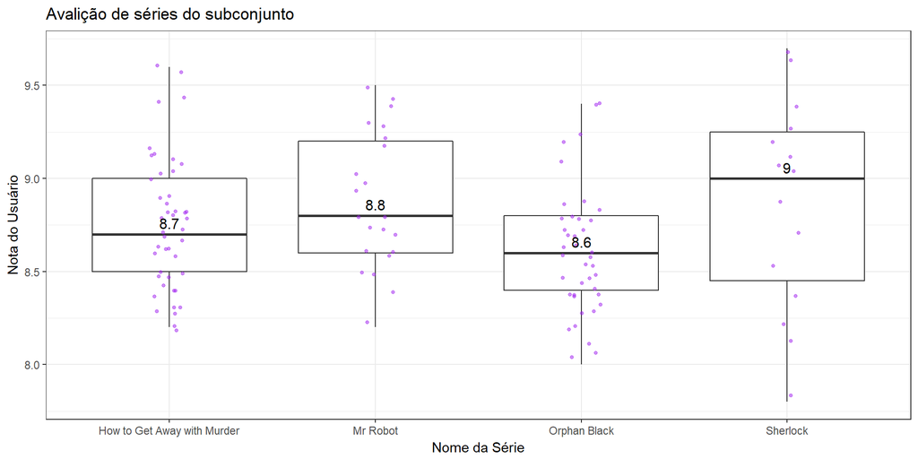

```r
series_filtradas %>%
  ggplot(aes(x = series_name,y = UserRating)) +
  geom_boxplot() + labs(title = "Avalição de séries do subconjunto", x= "Nome da Série", y= "Nota do Usuário") +
  geom_jitter(width = .1, size = 1, alpha = .5, color = "purple") +
  stat_summary(aes(label=round(..y..,2)), fun.y=median, geom="text", size=4, vjust = -0.5)
```

A partir do boxplot é possível observar que Sherlock é a série mais bem avaliada do nosso subconjunto, porém não fica distante das outras séries. A segunda colocada, por exemplo, é Mr Robot e está apenas 0.2 ponto abaixo da mais bem colocada. E a última colocada, Orphan Black está a 0.4 ponto abaixo de Sherlock.

**Pergunta 2: Qual das séries que você escolheu tem episódios de qualidade mais irregular segundo o IMDB? A diferença é grande? Pequena?**

Para responder essa pergunta voltaremos boxplot porém atentando para a distância entre quartis. Você pode consultar um pouco sobre essas medidas [aqui](http://www.escolaedti.com.br/o-que-e-um-box-plot/).

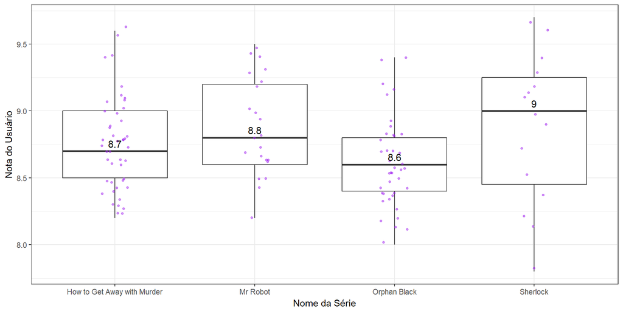

```r
series_filtradas %>%
  ggplot(aes(x = series_name,y = UserRating)) +
  geom_boxplot() + labs(x= "Nome da Série", y= "Nota do Usuário") +
  geom_jitter(width = .1, size = 1, alpha = .5, color = "purple") +
  stat_summary(aes(label=round(..y..,2)), fun.y=median, geom="text", size=4, vjust = -0.5)
```

É possível perceber que Sherlock é a série com o maior boxplot. Isso indica que há uma maior variação de notas entre os episódios, ou seja, uma irregularidade. Orphan Black é a série que tem a mediana mais próxima ao meio do boxplot (e possui o menor dentre as séries analisdas) e pode ser considerada como a mais regular.

Para destrinchar o que foi visto no boxplot observaremos o gráfico de linhas que mostra as notas de cada episódio de cada temporada. Vale observar que as séries não possuem o mesmo número de temporadas.

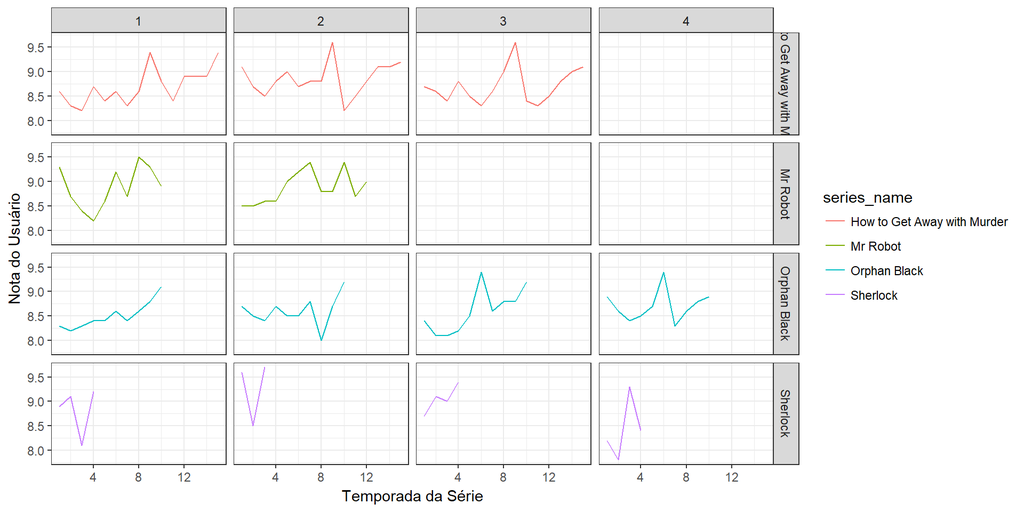

```r
series_filtradas %>%
  ggplot(aes(x = season_ep,y = UserRating, color = series_name)) +
  geom_line() +
  facet_grid(series_name~season)+ labs(x= "Temporada da Série", y= "Nota do Usuário")
```

Agora, analisando as séries por temporada, é possível perceber que Sherlock possui os grandes picos de qualidade. Apesar de ter poucos episódios ela não se mantém estável e isso reforça o que foi visto no boxplot. Porém, essa instabilidade em avaliações se repete para todas as séries. A primeira temporada de Orphan Black é a de mais continuidade, ou seja, onde não há grandes picos de avaliações positivas/negativas e contribui no boxplot ter mostrado essa série como a mais regular.